# Get started with Kotlin/Native

In this tutorial, you'll learn how to create a Kotlin/Native application. Choose the tool that works best for you and create your app using:

- The IDE. Here, you can clone the project template from a version control system and use it in IntelliJ IDEA.
- The Gradle build system. To better understand how things work under the hood, create build files for your project manually.
- The command line tool. You can use the Kotlin/Native compiler, which is shipped as a part of the standard Kotlin distribution, and create the app directly in the command line tool.

  Console compilation may seem easy and straightforward, but it doesn't scale well for larger projects with hundreds of files and libraries. For such projects, we recommend using an IDE or a build system.

With Kotlin/Native, you can compile for different targets, including Linux, macOS, and Windows. While cross-platform compilation is possible, which means using one platform to compile for a different one, in this tutorial, you'll be targeting the same platform you're compiling on.

## In IDE

In this section, you'll learn how to use IntelliJ IDEA to create a Kotlin/Native application.

### Create the project

1. Download and install the latest version of [IntelliJ IDEA](https://www.jetbrains.com/idea/).
2. Clone the [project template](https://github.com/Kotlin/kmp-native-wizard) by selecting File | New | Project from Version Control in IntelliJ IDEA and using this URL:

   ```
   https://github.com/Kotlin/kmp-native-wizard
   ```

3. Open the `gradle/libs.versions.toml` file, which is the version catalog for project dependencies. To create Kotlin/Native applications, you need the Kotlin Multiplatform Gradle plugin, which has the same version as Kotlin. Ensure that you use the latest Kotlin version:

   ```
   [versions]
   kotlin = "2.4.20"
   ```

4. Follow the suggestion to reload Gradle files:

[figure not shown]

For more information about these settings, see the Multiplatform Gradle DSL reference.

### Build and run the application

Press the green icon in the gutter to run the code:

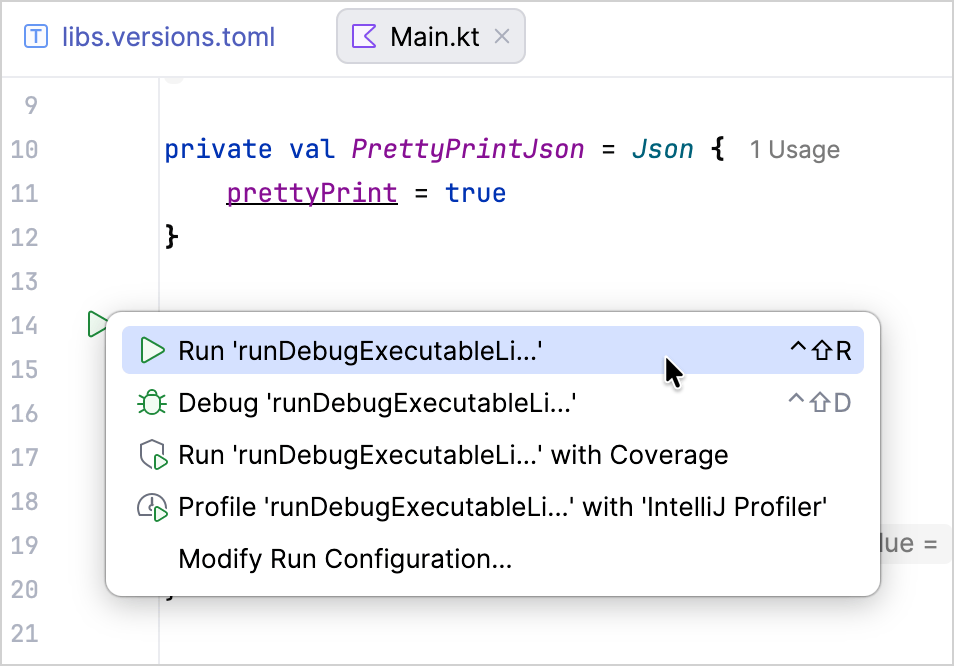

IntelliJ IDEA runs the code using the Gradle task and outputs the result in the Run tab:

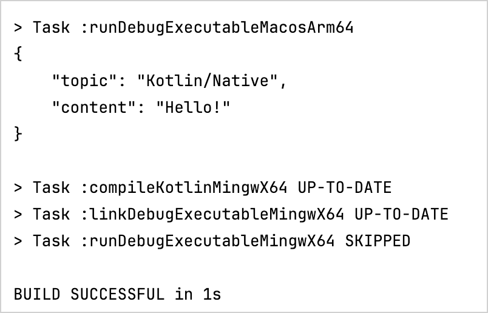

After the first run, the IDE creates the corresponding run configuration at the top:

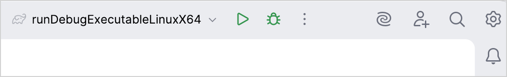

You can [configure IntelliJ IDEA](https://www.jetbrains.com/help/idea/compiling-applications.html#auto-build) to build your project automatically:

1. Go to Settings | Build, Execution, Deployment | Compiler.
2. On the Compiler page, select Build project automatically.
3. Apply the changes.

Now, when you make changes in the class files or save the file (`Ctrl + S`/`Cmd + S`), IntelliJ IDEA automatically performs an incremental build of the project.

### Update the application

Let's add a feature to your application so it can count the number of letters in your name:

1. In the `Main.kt` file, add code to read the input. Use the [`readln()`](https://kotlinlang.org/api/latest/jvm/stdlib/kotlin.io/readln.html) function to read the input value and assign it to the `name` variable:

   ```
   fun main() {
       // Read the input value.
       println("Hello, enter your name:")
       val name = readln()
   }
   ```

   ```
   fun main() {
       // Read the input value.
       println("Hello, enter your name:")
       val name = readln()
       // Count the letters in the name.
       name.replace(" ", "").let {
           println("Your name contains ${it.length} letters")
       }
   }
   ```

4. Run the application.
5. Enter your name and enjoy the result:

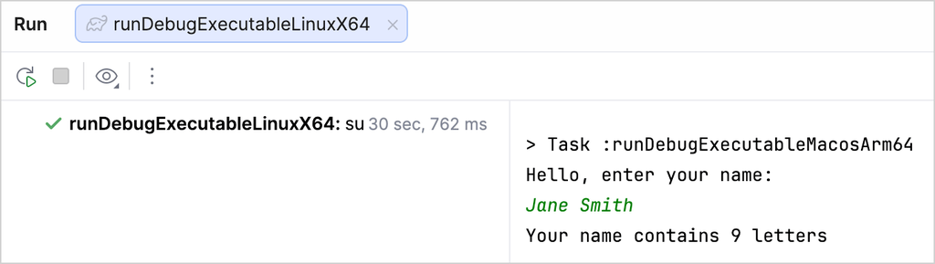

Now let's count only the unique letters in your name:

1. In the `Main.kt` file, declare the new extension function `.countDistinctCharacters()` for `String`:
   - Convert the name to lowercase using the [`.lowercase()`](https://kotlinlang.org/api/latest/jvm/stdlib/kotlin.text/lowercase.html) function.
   - Convert the input string to a list of characters using the [`toList()`](https://kotlinlang.org/api/latest/jvm/stdlib/kotlin.text/to-list.html) function.
   - Select only the distinct characters in your name using the [`distinct()`](https://kotlinlang.org/api/latest/jvm/stdlib/kotlin.collections/distinct.html) function.
   - Count the distinct characters using the [`count()`](https://kotlinlang.org/api/latest/jvm/stdlib/kotlin.collections/count.html) function.

   ```
   fun String.countDistinctCharacters() = lowercase().toList().distinct().count()
   ```

2. Use the `.countDistinctCharacters()` function to count the unique letters in your name:

   ```
   fun String.countDistinctCharacters() = lowercase().toList().distinct().count()

   fun main() {
       // Read the input value.
       println("Hello, enter your name:")
       val name = readln()
       // Count the letters in the name.
       name.replace(" ", "").let {
           println("Your name contains ${it.length} letters")
           // Print the number of unique letters.
           println("Your name contains ${it.countDistinctCharacters()} unique letters")
       }
   }
   ```

3. Run the application.
4. Enter your name and see the result:

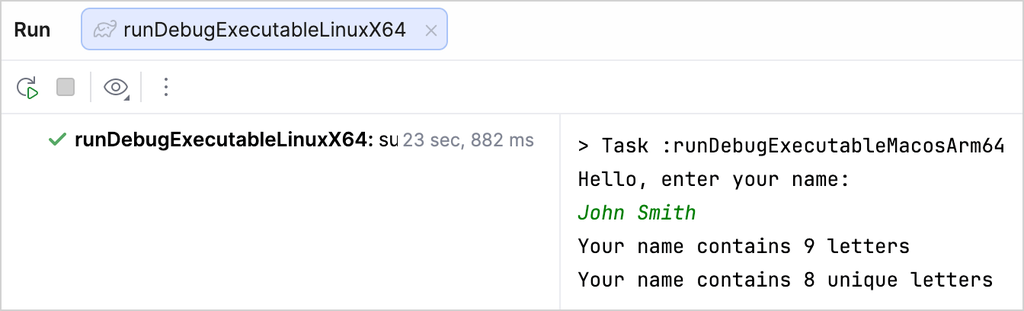

## Using Gradle

In this section, you'll learn how to manually create a Kotlin/Native application using [Gradle](https://gradle.org). It's the default build system for Kotlin/Native and Kotlin Multiplatform projects, which is also commonly used in Java, Android, and other ecosystems.

When building Kotlin/Native projects, the Kotlin Gradle plugin downloads the following artifacts:

- The main Kotlin/Native bundle, which includes different tools like `konanc`, `cinterop`, and `jsinterop`. By default, the Kotlin/Native bundle is downloaded from the [Maven Central](https://repo1.maven.org/maven2/org/jetbrains/kotlin/kotlin-native-prebuilt/) repository as a simple Gradle dependency.
- Dependencies required for `konanc` itself, like `llvm`. They are downloaded from the JetBrains CDN using custom logic.

You can change the source for the main bundle download in the `repositories {}` block in your Gradle build script.

### Create project files

1. To get started, install a compatible version of [Gradle](https://gradle.org/install/). See the compatibility table to check the Kotlin Gradle plugin (KGP) compatibility with available Gradle versions.
2. Create an empty project directory. Inside it, create a `build.gradle(.kts)` file with the following content:

   ```
   // build.gradle.kts
   import org.jetbrains.kotlin.gradle.plugin.mpp.KotlinNativeTarget

   plugins {
       kotlin("multiplatform") version "2.4.20"
   }

   repositories {
       // Specify the source to download the main bundle
       // Maven Central is used by default
       mavenCentral()
   }

   kotlin {
       macosArm64()    // on macOS
       // linuxArm64() // on Linux
       // mingwX64()   // on Windows

       targets.withType<KotlinNativeTarget>().configureEach {
           binaries {
               executable()
           }
       }
   }

   tasks.withType<Wrapper> {
       gradleVersion = "9.7.0"
       distributionType = Wrapper.DistributionType.BIN
   }
   ```

   ```
   // build.gradle
   import org.jetbrains.kotlin.gradle.plugin.mpp.KotlinNativeTarget

   plugins {
       id 'org.jetbrains.kotlin.multiplatform' version '2.4.20'
   }

   repositories {
       // Specify the source to download the main bundle
       // Maven Central is used by default
       mavenCentral()
   }

   kotlin {
       macosArm64()    // on macOS
       // linuxArm64() // on Linux
       // mingwX64()   // on Windows

       targets.withType(KotlinNativeTarget).configureEach {
           binaries {
               executable()
           }
       }
   }

   wrapper {
       gradleVersion = '9.7.0'
       distributionType = 'BIN'
   }
   ```

   You can use different target names, such as `macosArm64`, `iosArm64` `linuxArm64`, and `mingwX64` to define the targets for which you are compiling your code. The target name is used to generate the source paths and task names in the project.
3. Create an empty `settings.gradle(.kts)` file in the project directory.
4. Create a `src/nativeMain/kotlin` directory and place a `hello.kt` file inside with the following content:

   ```
   fun main() {
       println("Hello, Kotlin/Native!")
   }
   ```

By convention, all sources are located in the `src/<platform name>[Main|Test]/kotlin` directories, where `Main` is for the source code and `Test` is for tests. In this case, `<platform name>` is `native`.

### Build and run the project

1. From the root project directory, run the `<yourTargetName>Binaries` build command for your target, for example:

   ```
   ./gradlew macosArm64Binaries
   ```

   This command creates the `build/bin/<yourTargetName>` directory with two directories inside: `debugExecutable` and `releaseExecutable`. They contain the corresponding binary files.

The terminal prints "Hello, Kotlin/Native!".

### Open the project in IDE

Now, you can open your project in any IDE that supports Gradle. If you use IntelliJ IDEA:

1. Select File | Open.
2. Select the project directory and click Open. IntelliJ IDEA automatically detects if it's a Kotlin/Native project.

If you encounter a problem with the project, IntelliJ IDEA displays the error message in the Build tab.

## Using the command-line compiler

In this section, you'll learn how to create a Kotlin/Native application using the Kotlin compiler in the command line tool.

### Download and install the compiler

To install the compiler:

1. Go to the Kotlin's [GitHub releases](https://github.com/JetBrains/kotlin/releases/tag/v2.4.20) page and scroll down to the Assets section.
2. Look for a file with `kotlin-native` in the name and download one that is suitable for your operating system, for example `kotlin-native-prebuilt-linux-x86_64-2.4.20.tar.gz`.
3. Unpack the archive to a directory of your choice.
4. Open your shell profile and add the path to the compiler's `/bin` directory to the `PATH` environment variable:

   ```
   export PATH="/<path to the compiler>/kotlin-native/bin:$PATH"
   ```

### Create the program

Choose a working directory and create a file named `hello.kt`. Update it with the following code:

```
fun main() {
    println("Hello, Kotlin/Native!")
}
```

### Compile the code from the console

To compile the application, execute the following command with the downloaded compiler:

```
kotlinc-native hello.kt -o hello
```

The value of the `-o` option specifies the name of the output file, so this call generates the `hello.kexe` binary file on macOS and Linux (and `hello.exe` on Windows).

For the full list of available options, see Kotlin compiler options.

### Run the program

To run the program, in your command line tool, navigate to the directory containing the binary file and run the following command:

```
./hello.kexe
```

```
./hello.exe
```

The application prints "Hello, Kotlin/Native" to the standard output.

## What's next?

- Complete the Create an app using C interop and libcurl tutorial that explains how to create a native HTTP client and interoperate with C libraries.
- Learn how to write Gradle build scripts for real-life Kotlin/Native projects.
- Read more about the Gradle build system in the documentation.

21 May 2026

© 2010–2026 JetBrains s.r.o. and Kotlin Programming Language contributors  
Licensed under the Apache License, Version 2.0.  
https://kotlinlang.org/docs/native-get-started.html